# Sleep Duration and Cholesterol: Evidence from NHIS

Dylan Hilton & Isabelle Howerton

4/29/2020

## Setup

Load packages needed for the analysis. To install `lodown`, use `devtools::install_github()`.

```r
# Install dependencies (uncomment if needed)
#install.packages(c("tidyverse","devtools","survey","car","RDS"))
#devtools::install_github("ajdamico/lodown", dependencies = TRUE)

#library(mitools) # if using imputed income
#library(devtools)
library(lodown)
library(survey)
library(car)
library(RDS)
library(tidyverse)
```

Declare which year to use for the analysis.

```r
study_year = 2017
```

## Download data

Check whether NHIS data has already been downloaded for the study year. If not, use the [`lodown`](https://github.com/ajdamico/lodown) package to download the datasets and save them as `.rds` files in `<working directory>/data/<study_year>/`.

Then, merge the NHIS datasets using household, family, and person identifiers, `hhx`, `fmx`, and `fpx`. Save the merged dataset as `nhis_<study_year>.rds`.

```r
if(!file.exists(paste0("nhis_", study_year, ".rds"))) {
  # (Quietly) check which data are available for study_year
  invisible(capture.output(
    nhis_catalog <-
      get_catalog("nhis", output_dir = "data") %>% filter(year == study_year)
  ))

  # Download available data
  lodown("nhis", nhis_catalog)

  # Load data
  familyxx <-
    read_rds(paste0("data/", study_year, "/familyxx.rds"))
  househld <-
    read_rds(paste0("data/", study_year, "/househld.rds"))
  incmimp <- read_rds(paste0("data/", study_year, "/incmimp.rds"))
  personsx <-
    read_rds(paste0("data/", study_year, "/personsx.rds"))
  samadult <-
    read_rds(paste0("data/", study_year, "/samadult.rds"))
  funcdisb <-
    read_rds(paste0("data/", study_year, "/funcdisb.rds"))
  paradata <-
    read_rds(paste0("data/", study_year, "/paradata.rds"))

  # Merge datasets
  merged <- househld %>%
    left_join(familyxx, by = "hhx") %>%
    left_join(paradata, by = c("hhx", "fmx")) %>%
    left_join(personsx, by = c("hhx", "fmx")) %>%
    left_join(samadult, by = c("hhx", "fmx", "fpx")) %>%
    left_join(funcdisb, by = c("hhx", "fmx", "fpx")) %>%
    arrange(hhx, fmx, fpx)

  # Export dataset as .rds
  write_rds(merged, paste0("nhis_", study_year, ".rds"))

  # Delete merged objects
  rm(familyxx,
     househld,
     incmimp,
     personsx,
     samadult,
     funcdisb,
     merged)
  gc()
}
```

## Recode variables

Load `nhis_<study_year>.rds`, and decide which variables to keep for the analysis. Some variables, such as identifiers and survey design information, should not be removed.

Convert variables to factors or integers as needed, keeping in mind that `dplyr::case_when()` returns `NA` if a case doesn’t match any recode criteria. Label factor levels according to the [NHIS documentation](https://www.cdc.gov/nchs/nhis/nhis_2017_data_release.htm).

```r
sample <- read_rds(paste0("nhis_", study_year, ".rds")) %>%

  # Decalare which variables to keep, convert to factor, apply recodes
  transmute(
    # Merge variables -- do not remove
    # unique id
    id = paste0(hhx, fmx, fpx),
    # household id
    hhx = as.double(hhx),
    # family id
    fmx = as.double(fmx),
    # person id
    fpx = as.double(fpx),


    # Survey design variables -- do not remove
    # psu (cluster)
    ppsu = as.integer(ppsu.x),
    # stratum
    pstrat = as.integer(pstrat.x),
    # weight after post-stratification adjustments (for sample adult)
    wtfa_sa = as.integer(wtfa_sa),
    # complete/partial/incomplete response
    outcome1 = outcome1,
    # sample adult flag
    astatflg = astatflg,

    # Analysis variables -- free to change
    # age
    age = age_p.x,

    # sex
    sex = case_when(sex.x == 1 ~ "Male",
                    sex.x == 2 ~ "Female") %>% factor(),

    # race
    race = case_when(
      racerpi2.x == 1 ~ "White",
      racerpi2.x == 2 ~ "Black/African American",
      racerpi2.x == 3 ~ "AIAN",
      racerpi2.x == 4 ~ "Asian",
      racerpi2.x == 6 ~ "Multiple race"
    ) %>% fct_relevel(),

    # highest level of education completed
    education = case_when(
      educ1 <= 12 ~ "No diploma",
      educ1 %in% c(13, 14) ~ "High school",
      educ1 %in% c(15, 16, 17) ~ "Some college or Associate's",
      educ1 == 18 ~ "Bachelor's degree",
      educ1 %in% c(19, 20, 21) ~ "Advanced degree"
    ) %>% factor(),

    # Respondent reported functional limitation (la1ar) and mentioned a heart
    # problem as a cause (lahca7)
    heart_limitation = case_when(
      la1ar == 2 ~ "No",
      la1ar == 1 & lahca7 == 1 ~ "Yes",
      la1ar == 1 & lahca7 == 2 ~ "No",
    ) %>% factor(),

    # told to increase physical activity, past 12 m
    told_increase_pa = case_when(dbhvpay == 1 ~ "Yes",
                                 dbhvpay == 2 ~ "No") %>% factor(),

    # told to reduce fat/calories in diet, past 12 m
    told_improve_diet = case_when(dbhvcly == 1 ~ "Yes",
                                  dbhvcly == 2 ~ "No") %>% factor(),

    # ever told high cholesterol
    high_cholesterol_ever = case_when(chlev == 1 ~ "Yes",
                                      chlev == 2 ~ "No") %>% factor(),

    # average hours of sleep in 24-hour period
    hours_sleep = as.integer(case_when(
      asisleep %in% c(97, 98, 99) ~ NA_integer_,
      TRUE ~ as.integer(asisleep)
    ))
  ) %>%

  # Filter out non-responses
  filter(outcome1 %in% c(201, 203)) %>%

  # Include only respondents chosen for sample adult interview
  # Responses are weighted at each stage of sampling -- this exclusion should be fine
  filter(astatflg == 1) %>%

  # Add complete-case indicator. Don't drop them, but subset using survey design.
  mutate(complete = complete.cases(.))
```

## Survey design

Use the [`survey`](https://cran.r-project.org/web/packages/survey/survey.pdf) package to account for the sampling, stratification, and weights from the NHIS design.

```r
# For all sample adult respondents:
nhis_design <-
  svydesign(
    id = ~ ppsu,
    strata = ~ pstrat,
    nest = TRUE,
    weights = ~ wtfa_sa,
    data = sample
  )
```

An exclusion criteria of this study is reporting a functional limitation attributable to a heart problem. Create a `subset` of `nhis_design` that excludes these respondents.

```r
# Subset data to exclude those reporting a limitation:
no_heart_lim <- subset(nhis_design, heart_limitation == "No")
```

```r
nrow(no_heart_lim$variables)
```

```
## [1] 26064
```

## Visualize

Use a box plot to visually determine whether there is a difference in the average number of hours slept by high cholesterol status.

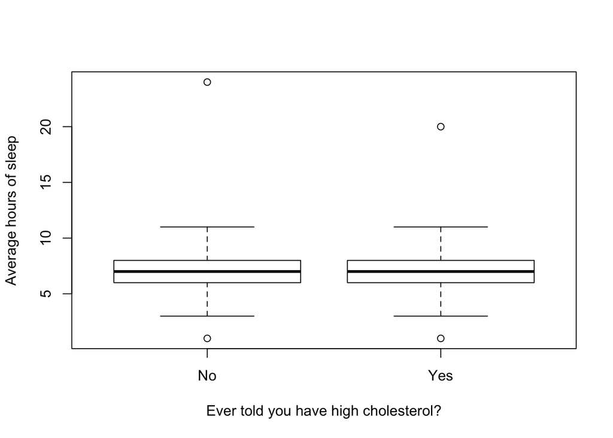

```r
# Visualize data
svyboxplot(
  hours_sleep ~ high_cholesterol_ever,
  xlab = "Ever told you have high cholesterol?",
  ylab = "Average hours of sleep",
  design = no_heart_lim
)
```

At first glance, there isn’t a difference in mean hours of sleep between the two groups.

## Test assumptions

### Linearity

Use the Box-Tidwell test to determine whether numeric variables (`hours_sleep` and `age`) meet the linearity assumption.

```r
# Add interaction terms of the format IV*log(IV)
# do for all numeric variables
no_heart_lim <- update(
  no_heart_lim,
  sleep_log_sleep = hours_sleep * log(hours_sleep),
  age_log_age = age * log(age)
)

# Box-Tidwell test: a significant result means the assumption is violated and
# the independent variable should be transformed.
box_tidwell_sleep <-
  svyglm(
    high_cholesterol_ever ~ hours_sleep + sleep_log_sleep,
    design = no_heart_lim,
    family = binomial
  )

box_tidwell_age <-
  svyglm(high_cholesterol_ever ~ age + age_log_age,
         design = no_heart_lim,
         family = binomial)

# Print results
summary(box_tidwell_sleep)
```

```
##
## Call:
## svyglm(formula = high_cholesterol_ever ~ hours_sleep + sleep_log_sleep,
##     design = no_heart_lim, family = binomial)
##
## Survey design:
## update(no_heart_lim, sleep_log_sleep = hours_sleep * log(hours_sleep),
##     age_log_age = age * log(age))
##
## Coefficients:
##                 Estimate Std. Error t value Pr(>|t|)
## (Intercept)      0.67577    0.39443   1.713   0.0873 .
## hours_sleep     -0.66884    0.16011  -4.177 3.50e-05 ***
## sleep_log_sleep  0.22270    0.05343   4.168 3.65e-05 ***
## ---
## Signif. codes:  0 '***' 0.001 '**' 0.01 '*' 0.05 '.' 0.1 ' ' 1
##
## (Dispersion parameter for binomial family taken to be 1.000873)
##
## Number of Fisher Scoring iterations: 4
```

```r
summary(box_tidwell_age)
```

```
##
## Call:
## svyglm(formula = high_cholesterol_ever ~ age + age_log_age, design = no_heart_lim,
##     family = binomial)
##
## Survey design:
## update(no_heart_lim, sleep_log_sleep = hours_sleep * log(hours_sleep),
##     age_log_age = age * log(age))
##
## Coefficients:
##              Estimate Std. Error t value Pr(>|t|)
## (Intercept) -7.827615   0.501802 -15.599   <2e-16 ***
## age          0.486034   0.046455  10.462   <2e-16 ***
## age_log_age -0.087991   0.009249  -9.513   <2e-16 ***
## ---
## Signif. codes:  0 '***' 0.001 '**' 0.01 '*' 0.05 '.' 0.1 ' ' 1
##
## (Dispersion parameter for binomial family taken to be 1.036997)
##
## Number of Fisher Scoring iterations: 5
```

A significant result suggests that both `hours_sleep` and `age` should be transformed. Create `sleep_above_mean`, which categorizes cases as above or below the survey mean for `hours_sleep`, and `age_cat`, which divides `age` into categories.

```r
# Calculate mean hours of sleep
mean_sleep <-
  data.frame(svymean(~ hours_sleep, design = no_heart_lim, na.rm = TRUE))[1, 1]

mean_sleep
```

```
## [1] 7.066007
```

```r
# Add new variables
no_heart_lim$variables <- no_heart_lim$variables %>%
  mutate(
    # Categorize cases based on mean_sleep
    sleep_above_mean = case_when(hours_sleep >= mean_sleep ~ TRUE,
                                 TRUE ~ FALSE),

    # Categorize cases based on age
    age_cat = case_when(
      age <= 34 ~ "18 to 34",
      between(age, 35, 49) ~ "35 to 49",
      between(age, 50, 70) ~ "50 to 70",
      age >= 70 ~ "70+"
    ) %>% factor()
  )
```

Examine the distribution of the recoded variables:

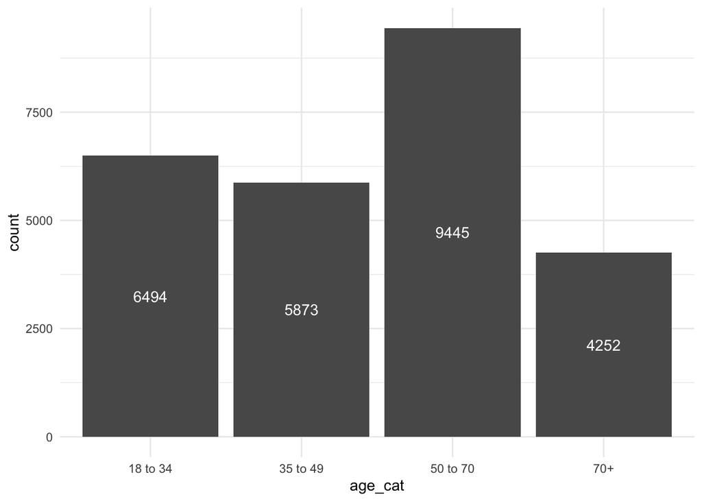

```r
# Plot
no_heart_lim$variables %>%
  ggplot(aes(age_cat)) +
  stat_count() +
  geom_text(
    stat = 'count',
    aes(label = ..count..),
    color = "white",
    position = position_stack(vjust = 0.5)
  ) +
  theme_minimal()
```

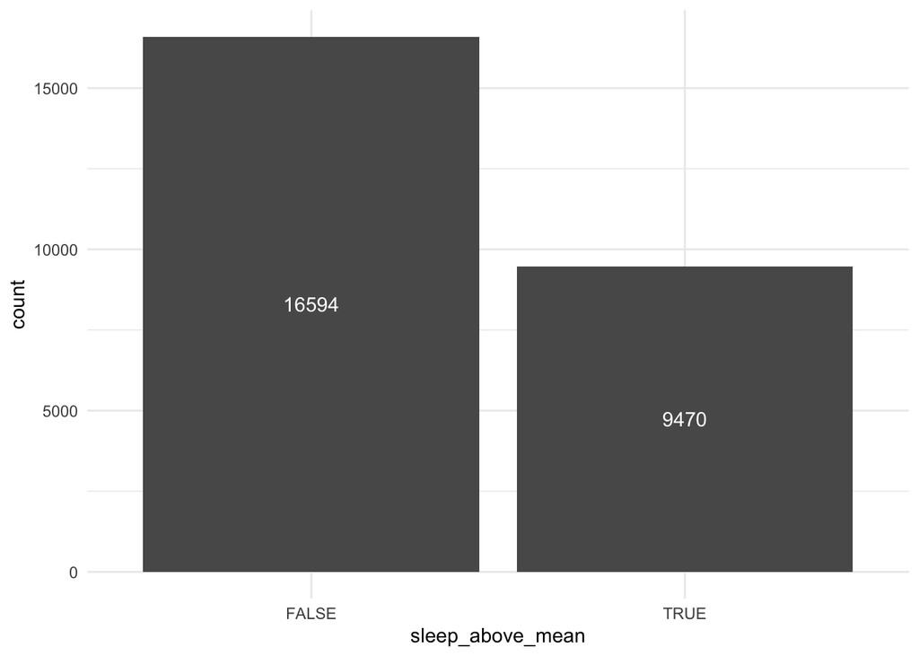

```r
no_heart_lim$variables %>%
  ggplot(aes(sleep_above_mean)) +
  stat_count() +
  geom_text(
    stat = 'count',
    aes(label = ..count..),
    color = "white",
    position = position_stack(vjust = 0.5)
  ) +
  theme_minimal()
```

## Fit models

### Make a complete-cases dataset

```r
complete_cases <- subset(no_heart_lim, complete == TRUE)
```

### Univariate model: sleep only

```r
# Sleep-only model
sparse_model  <- svyglm(high_cholesterol_ever ~ sleep_above_mean,
                        design = complete_cases,
                        family = binomial)

# Odds ratios
RDS:::summary.svyglm.RDS(sparse_model)
```

```
##
## Call:
## svyglm(formula = high_cholesterol_ever ~ sleep_above_mean, design = complete_cases,
##     family = binomial)
##
## Survey design:
## subset(no_heart_lim, complete == TRUE)
##
## Odds Ratios
##                      Estimate  Lower Upper Pr(>|t|)
## (Intercept)            0.3872 0.3673 0.408   <2e-16 ***
## sleep_above_meanTRUE   1.0116 0.9405 1.088    0.755
## ---
## Signif. codes:  0 '***' 0.001 '**' 0.01 '*' 0.05 '.' 0.1 ' ' 1
##
## (Dispersion parameter for binomial family taken to be 1.00004)
##
## Number of Fisher Scoring iterations: 4
##
##  Warning: The model fit currently only adjusts for the first-order RDS weights, and not other complexities of the sampling.
##   The numerical summaries should be interpreted with caution.
```

### Multivariate model: all covariates

```r
# Model with covariates
full_model <- svyglm(
  high_cholesterol_ever ~ sleep_above_mean
  + age_cat + sex + race + education + told_increase_pa + told_improve_diet,
  design = complete_cases,
  family = binomial
)

# Odds ratios
RDS:::summary.svyglm.RDS(full_model)
```

```
##
## Call:
## svyglm(formula = high_cholesterol_ever ~ sleep_above_mean + age_cat +
##     sex + race + education + told_increase_pa + told_improve_diet,
##     design = complete_cases, family = binomial)
##
## Survey design:
## subset(no_heart_lim, complete == TRUE)
##
## Odds Ratios
##                                      Estimate    Lower  Upper Pr(>|t|)
## (Intercept)                           0.05411  0.03478  0.084  < 2e-16 ***
## sleep_above_meanTRUE                  0.96452  0.89033  1.045    0.376
## age_cat35 to 49                       3.03070  2.56816  3.577  < 2e-16 ***
## age_cat50 to 70                       7.72518  6.63340  8.997  < 2e-16 ***
## age_cat70+                           13.81714 11.75873 16.236  < 2e-16 ***
## sexMale                               1.29116  1.18483  1.407 9.64e-09 ***
## raceAsian                             1.00777  0.64633  1.571    0.973
## raceBlack/African American            0.72565  0.47276  1.114    0.142
## raceMultiple race                     0.69132  0.42689  1.120    0.133
## raceWhite                             0.94873  0.62762  1.434    0.802
## educationBachelor's degree            1.04145  0.92116  1.177    0.516
## educationHigh school                  0.96557  0.84937  1.098    0.592
## educationNo diploma                   1.04045  0.88951  1.217    0.619
## educationSome college or Associate's  1.05575  0.93689  1.190    0.373
## told_increase_paYes                   1.59845  1.45425  1.757  < 2e-16 ***
## told_improve_dietYes                  2.39752  2.16187  2.659  < 2e-16 ***
## ---
## Signif. codes:  0 '***' 0.001 '**' 0.01 '*' 0.05 '.' 0.1 ' ' 1
##
## (Dispersion parameter for binomial family taken to be 0.9791534)
##
## Number of Fisher Scoring iterations: 5
##
##  Warning: The model fit currently only adjusts for the first-order RDS weights, and not other complexities of the sampling.
##   The numerical summaries should be interpreted with caution.
```

## Test assumptions in the full model

### Influence

Compute dfbetas using `svydiags::svydfbetas()`, and flag influential cases where $DFBETA\geq \frac{2}{\sqrt{n}}$.

```r
# Calculate dfbetas according to survey design
dfb <-
  svydiags::svydfbetas(full_model,
                       stvar = "pstrat",
                       clvar = "ppsu",
                       z = 2)

# Name columns
dfbs <- data.frame(t(dfb$Dfbetas))
names(dfbs) <- paste0("dfbs_", names(full_model$coefficients))

# Flag influential observations with any dfbeta >= 2/sqrt(n)
dfbs <- dfbs %>%
  mutate(influential = ifelse(rowSums(dfbs >= dfb$cutoff) > 0,
                              1,
                              0))

# Join dfbetas to data
full_model_dfbs <- cbind(full_model$data, dfbs)

# Number of influential observations
full_model_dfbs %>% group_by(influential) %>% summarize(n())
```

```
## # A tibble: 2 x 2
##   influential `n()`
##         <dbl> <int>
## 1           0 24938
## 2           1    70
```

### Multicollinearity

Compute variance inflation factor using `svydiags::svyvif()`. Calculating VIF while taking into account survey weights takes a long time and can exhaust R’s memory limit. For convenience, the pre-calculated values are saved in `vif.rds`. Delete `vif.rds` to force re-calculation.

```r
if(file.exists("vif.rds")) {

  # Load the pre-calculated object:
  vif <- read_rds("vif.rds")

} else {
  # If the file is missing, generate vif.rds

  # Calculate covariance matrix
  covariance_matrix <-
    svydiags::Vmat(full_model, stvar = "pstrat", clvar = "ppsu")

  # Get design matrix
  model_matrix <-
    model.matrix(full_model$formula, data = full_model$data)

  # Calculate VIF
  vif <-
    svydiags::svyvif(model_matrix, full_model$weights, covariance_matrix)

  # Save to file
  write_rds(vif, "vif.rds")

  # Free up space
  rm(covariance_matrix)
}

# Print results
vif
```

```
##                                        svy.vif       reg.vif     zeta    varrho
## (Intercept)                                Inf -5.763604e+13 1.308826      -Inf
## sleep_above_meanTRUE                  1.033282  1.029090e+00 2.693282 0.3728065
## age_cat35 to 49                       1.271894  2.276979e+00 1.741010 0.3208415
## age_cat50 to 70                       1.329767  2.555063e+00 1.165627 0.4464928
## age_cat70+                            1.335824  1.980730e+00 1.152645 0.5850973
## sexMale                               1.007838  1.011424e+00 2.483878 0.4011687
## raceAsian                             3.790892  6.126357e+00 2.203702 0.2807930
## raceBlack/African American            7.482703  9.255395e+00 1.822267 0.4436613
## raceMultiple race                     2.716149  2.325033e+00 1.855719 0.6295239
## raceWhite                            11.408032  1.406645e+01 1.945062 0.4169585
## educationBachelor's degree            1.963144  2.035279e+00 2.150463 0.4485348
## educationHigh school                  1.922340  2.153050e+00 2.185124 0.4086014
## educationNo diploma                   1.449016  1.690740e+00 3.488629 0.2456640
## educationSome college or Associate's  2.087199  2.297576e+00 2.037031 0.4459606
## told_increase_paYes                   1.380900  1.464598e+00 2.239250 0.4210572
## told_improve_dietYes                  1.278496  1.475638e+00 2.498206 0.3468098
##                                      zeta.x.varrho
## (Intercept)                                   -Inf
## sleep_above_meanTRUE                     1.0040731
## age_cat35 to 49                          0.5585882
## age_cat50 to 70                          0.5204440
## age_cat70+                               0.6744097
## sexMale                                  0.9964543
## raceAsian                                0.6187841
## raceBlack/African American               0.8084693
## raceMultiple race                        1.1682193
## raceWhite                                0.8110101
## educationBachelor's degree               0.9645574
## educationHigh school                     0.8928448
## educationNo diploma                      0.8570306
## educationSome college or Associate's     0.9084355
## told_increase_paYes                      0.9428526
## told_improve_dietYes                     0.8664021
```

# Final model

Fit a final model using all covariates, excluding influential values.

```r
# join influential column from full_model_dfbs
complete_cases$variables <- complete_cases$variables %>%
  left_join(full_model_dfbs %>% select(id, influential))
# Re-fit model, excluding influential cases
final_model <- svyglm(
  high_cholesterol_ever ~ sleep_above_mean
  + age_cat + sex + race + education + told_increase_pa + told_improve_diet,
  design = complete_cases,
  subset = influential == 0,
  family = binomial
)
# Get odds ratios and CIs
RDS:::summary.svyglm.RDS(final_model)
```

```
##
## Call:
## svyglm(formula = high_cholesterol_ever ~ sleep_above_mean + age_cat +
##     sex + race + education + told_increase_pa + told_improve_diet,
##     design = complete_cases, subset = influential == 0, family = binomial)
##
## Survey design:
## subset(no_heart_lim, complete == TRUE)
##
## Odds Ratios
##                                      Estimate    Lower  Upper Pr(>|t|)
## (Intercept)                           0.02599  0.01802  0.037  < 2e-16 ***
## sleep_above_meanTRUE                  0.96565  0.89223  1.045 0.385545
## age_cat35 to 49                       3.27361  2.76575  3.875  < 2e-16 ***
## age_cat50 to 70                       8.75455  7.52124 10.190  < 2e-16 ***
## age_cat70+                           15.75150 13.44904 18.448  < 2e-16 ***
## sexMale                               1.29430  1.19103  1.407 2.28e-09 ***
## raceAsian                             1.87318  1.27125  2.760 0.001562 **
## raceBlack/African American            1.38395  0.96702  1.981 0.075527 .
## raceMultiple race                     1.06327  0.69730  1.621 0.775202
## raceWhite                             1.80558  1.28604  2.535 0.000676 ***
## educationBachelor's degree            1.00981  0.89417  1.140 0.874697
## educationHigh school                  0.94059  0.82901  1.067 0.340967
## educationNo diploma                   0.95765  0.82702  1.109 0.562287
## educationSome college or Associate's  1.02452  0.91181  1.151 0.683095
## told_increase_paYes                   1.59443  1.45143  1.752  < 2e-16 ***
## told_improve_dietYes                  2.38716  2.16519  2.632  < 2e-16 ***
## ---
## Signif. codes:  0 '***' 0.001 '**' 0.01 '*' 0.05 '.' 0.1 ' ' 1
##
## (Dispersion parameter for binomial family taken to be 0.9817102)
##
## Number of Fisher Scoring iterations: 5
##
##  Warning: The model fit currently only adjusts for the first-order RDS weights, and not other complexities of the sampling.
##   The numerical summaries should be interpreted with caution.
```

Compare coefficients of the three models:

```r
# Compare coefficients with other models
compareCoefs(sparse_model, full_model, final_model)
```

```
## Calls:
## 1: svyglm(formula = high_cholesterol_ever ~ sleep_above_mean, design =
##   complete_cases, family = binomial)
## 2: svyglm(formula = high_cholesterol_ever ~ sleep_above_mean + age_cat +
##   sex + race + education + told_increase_pa + told_improve_diet, design =
##   complete_cases, family = binomial)
## 3: svyglm(formula = high_cholesterol_ever ~ sleep_above_mean + age_cat +
##   sex + race + education + told_increase_pa + told_improve_diet, design =
##   complete_cases, subset = influential == 0, family = binomial)
##
##                                      Model 1 Model 2 Model 3
## (Intercept)                          -0.9489 -2.9167 -3.6502
## SE                                    0.0267  0.2249  0.1863
##
## sleep_above_meanTRUE                  0.0116 -0.0361 -0.0350
## SE                                    0.0371  0.0407  0.0402
##
## age_cat35 to 49                               1.1088  1.1859
## SE                                            0.0843  0.0858
##
## age_cat50 to 70                               2.0445  2.1696
## SE                                            0.0775  0.0773
##
## age_cat70+                                    2.6259  2.7569
## SE                                            0.0821  0.0804
##
## sexMale                                       0.2555  0.2580
## SE                                            0.0437  0.0423
##
## raceAsian                                    0.00774 0.62764
## SE                                           0.22604 0.19727
##
## raceBlack/African American                    -0.321   0.325
## SE                                             0.218   0.182
##
## raceMultiple race                            -0.3691  0.0613
## SE                                            0.2453  0.2147
##
## raceWhite                                    -0.0526  0.5909
## SE                                            0.2103  0.1727
##
## educationBachelor's degree                   0.04062 0.00977
## SE                                           0.06246 0.06190
##
## educationHigh school                         -0.0350 -0.0613
## SE                                            0.0653  0.0643
##
## educationNo diploma                           0.0396 -0.0433
## SE                                            0.0798  0.0746
##
## educationSome college or Associate's          0.0542  0.0242
## SE                                            0.0608  0.0593
##
## told_increase_paYes                           0.4690  0.4665
## SE                                            0.0481  0.0478
##
## told_improve_dietYes                          0.8744  0.8701
## SE                                            0.0526  0.0497
##
```

# Assess goodness-of-fit

Likelihood ratio tests cannot be used with survey data because the [independence assumption](https://towardsdatascience.com/maximum-likelihood-estimation-explained-normal-distribution-6207b322e47f#2555) of the underlying maximum likelihood estimation is violated. Instead, [Wald tests](https://www.stata.com/support/faqs/statistics/likelihood-ratio-test/) or a [modified Hosmer-Lemeshow test](https://journals.sagepub.com/doi/pdf/10.1177/1536867X0600600106) (not currently implemented in R) should be used.

`car::Anova()` produces type-II Wald tests [by default](https://socialsciences.mcmaster.ca/jfox/Books/Companion/appendices/Appendix-Surveys.pdf) when passed a `svyglm` object.

In this test, the null hypothesis is that the coefficient is zero and failing to reject the null hypothesis suggests that removing the variable will not harm the fit of the model. **In other words, a significant result means we should keep the variable.**

```r
# Sleep-only model
Anova(sparse_model)
```

```
## Analysis of Deviance Table (Type II tests)
##
## Response: high_cholesterol_ever
##                  Df  Chisq Pr(>Chisq)
## sleep_above_mean  1 0.0971     0.7553
```

```r
# Model with covariates
Anova(final_model)
```

```
## Analysis of Deviance Table (Type II tests)
##
## Response: high_cholesterol_ever
##                   Df     Chisq Pr(>Chisq)
## sleep_above_mean   1    0.7544     0.3851
## age_cat            3 1519.0373  < 2.2e-16 ***
## sex                1   37.1625  1.087e-09 ***
## race               4   39.4920  5.513e-08 ***
## education          4    2.6459     0.6187
## told_increase_pa   1   95.1781  < 2.2e-16 ***
## told_improve_diet  1  306.9118  < 2.2e-16 ***
## ---
## Signif. codes:  0 '***' 0.001 '**' 0.01 '*' 0.05 '.' 0.1 ' ' 1
```